# Animal Behavior

## Why is that crab waving at me?

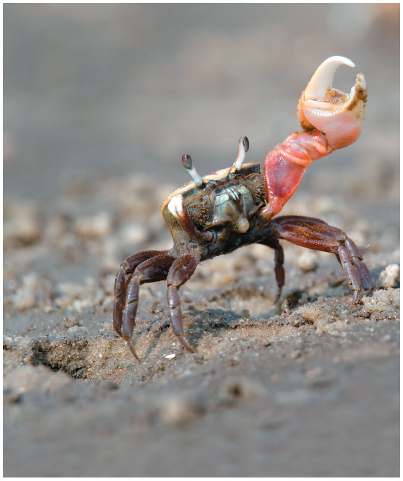

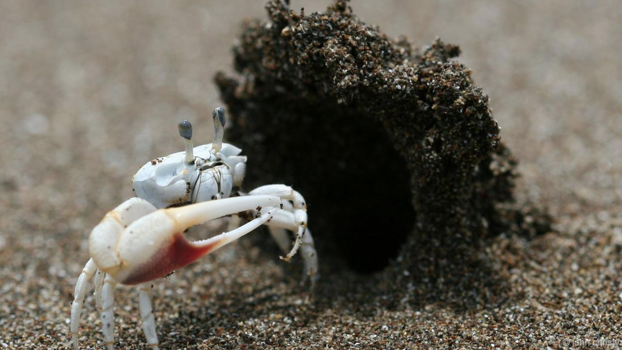

## Animal behavior hash-tags

- **This lecture will cover the evolution of animal behaviors across the animal phylogeny**
  - understand each of Tinbergen’s questions and know examples for each
- **#Tinbergen Questions**

## The big picture: Animal behavior

- **Behavior: an action carried out by muscles under control of the nervous system**
  - works via sensory pathway in nervous systems
- **Genes often underlie the capacity for a behavior**
  - allows for evolution by natural selection
- **Learning connects experience and behavior**
  - Genetics x Environment

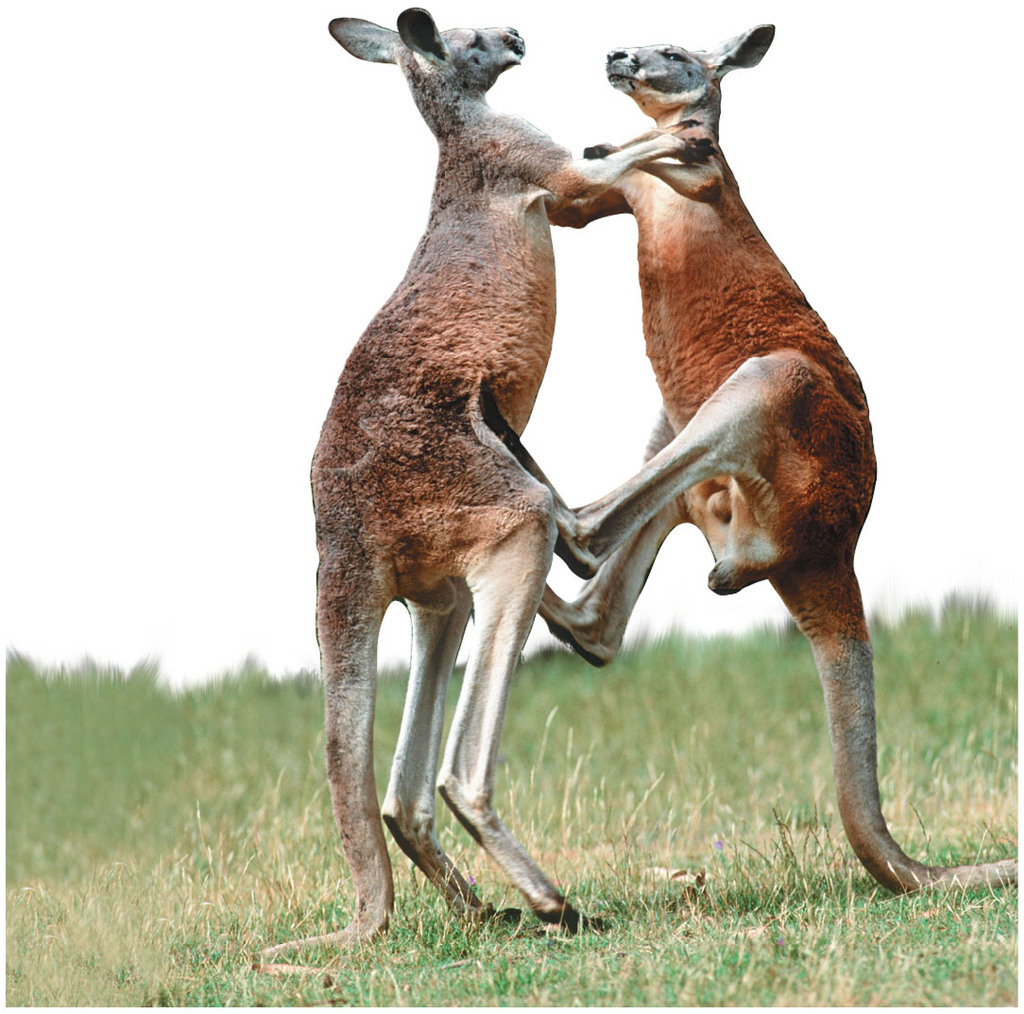

## Niko Tinbergen: Understanding animal behavior…

- **Q1. What stimulus elicits the behavior, and what physiological mechanisms bring about the response?**
- **Q2. How does the animal’s experience during growth and development influence the response?**
- **Q3. How does the behavior aid survival and reproduction?**
- **Q4. What is the behavior’s evolutionary history?**

**Take home message: Behaviors are not just a spontaneous reaction to a stimulus**

[figure not shown]

## Fixed action patterns

- **Q1: what stimuli trigger behaviors…**
  - Tinbergen kept fish tanks with stickleback fish
  - Males = red belly; Females= no red belly
- **Male territorial behavior related to red color**
  - males behaved aggressively when anything red was added to the tank
- **What mechanism regulates the response…?**
  - Fixed Action Pattern:
  - developmentally ‘fixed’ → *innate* behavior
  - trigger = *specific stimulus* (i.e. red color)

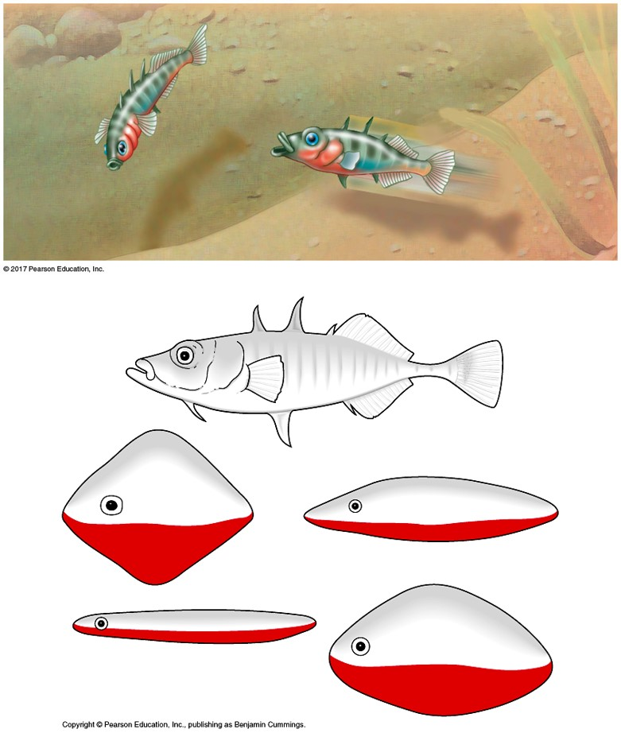

## Environmental cues for behavior: Migration

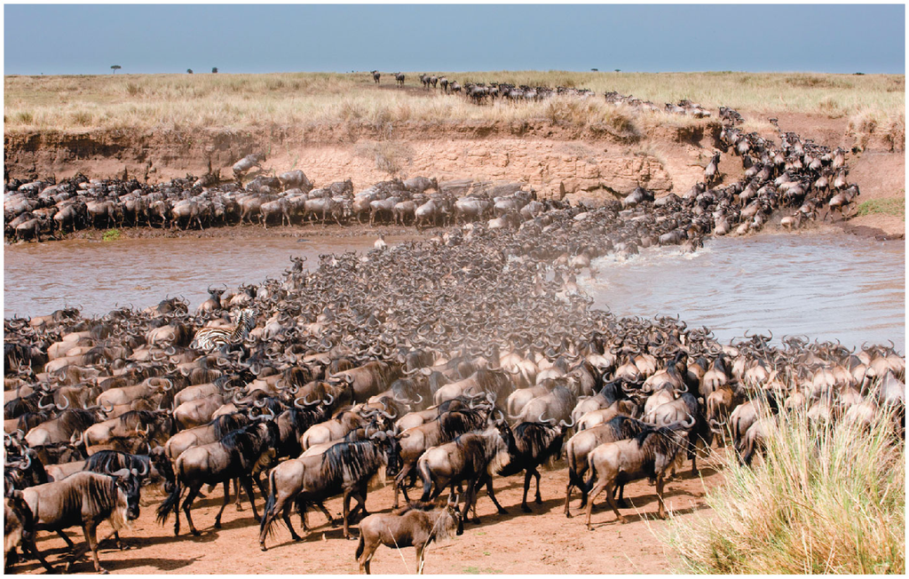

## Homing pigeon returning home

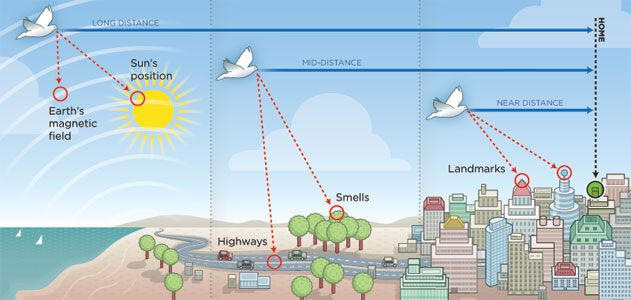

## Rhythm is gonna get you

- **Animal behaviors also reflect circadian rhythms (Q1)**
  - biological clocks or longer environmental cycles
- **Migration and reproduction cued by seasonal cycles**
  - periods of day length or temperature cues
- **Behaviors rhythms can be related to lunar cycles**
  - includes tides (e.g. crab reproduction, turtle nesting)

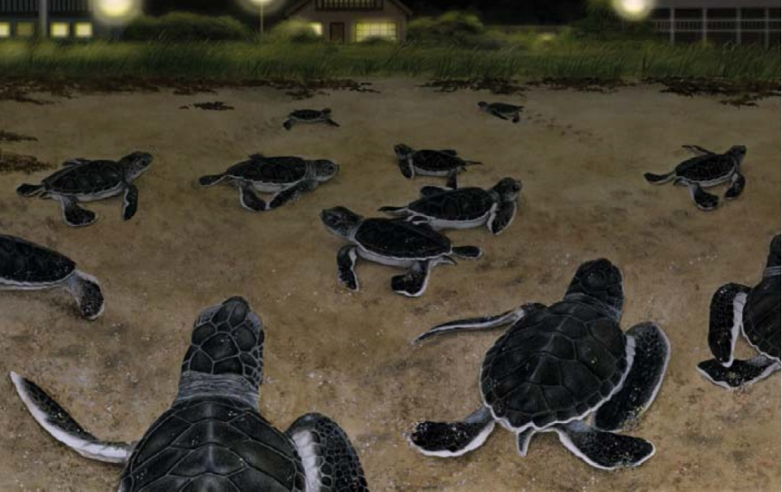

## Forms of animal communication

- **Stimuli also come from other animals (Q1)**
- **Signal: a variety of mechanisms to communicate**
  - male waving claw at female crab
- **Communication: transmission and reception of signals**
  - plays a role in primary cause (‘the How’)
- **4 common modes of animal communication**
  - visual, chemical, tactile & auditory

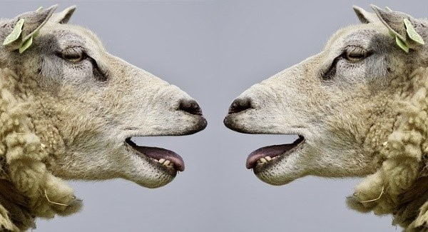

## Fruit fly courtship use all 4 modes of communication

- **Step 1: Male *sees* female and orients towards her**
  - uses olfactory *chemical* system to determine species
- **Step 2: Male *touches* female with foreleg**
  - alerts female to his presence
- **Step 3: Male vibrates wing for courtship song**
  - *auditory* behaviors shows female he is ‘fit’
- **If all communications are successful → sexy time**

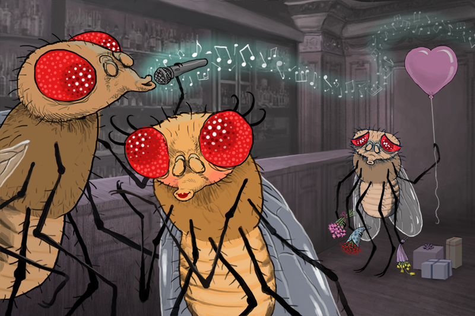

## https://www.youtube.com/watch?v=KzWIuhXMUko

[video not shown]

## Forms of communication evolve with animal’s environment

- **Many terrestrial mammals are nocturnal**
  - use olfactory and auditory forms
  - usually are color blind
- **Humans and most birds are diurnal**
  - use visual and auditory forms
  - lack many olfactory cues
- **The amount of information communicated varies**
  - Bees communicate flower location using special dances. One bee dances, while other bees watch to learn the directions to a specific flower patch. The dancing bee smells like the flower patch, and also gives the watching bees a taste of the nectar she gathered. Smell and taste helps other bees find the correct flower patch.

[figure not shown]

## Experience and behavior

- **Q2: How does the animal’s experience during growth and development influence behavior?**
- **Which behaviors are innate (fixed) and which are learned?**
  - cross-fostering & human twin studies separate ‘nature from nurture’

[figure not shown]

## The capacity to *learn* in the animal kingdom

- **Learning: Modifications of behaviors as a result of experience**
- **Learning capacity → nervous system organization during development**
  - genome encoded (the behavior exists)
- **Both nature (genes) vs nurture (environment)**
  - finches can sing, but learn song from father
- **Learning Types: Imprinting, Spatial, Associative, Cognitive, Social**

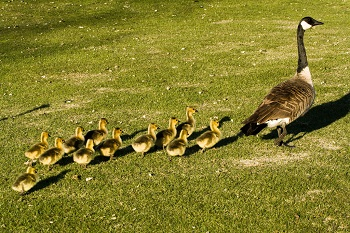

## Landmarks (Spatial) + Trial and Error (Associative)

[figure not shown]

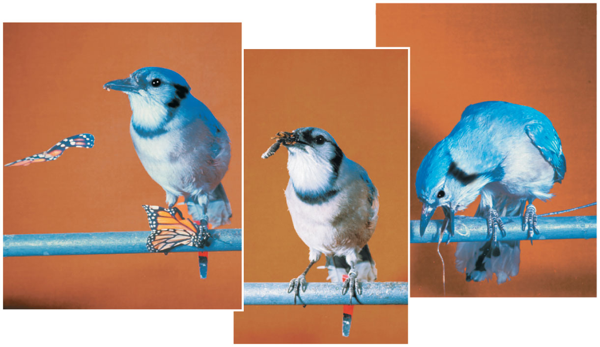

## Trouble with assembling IKEA furniture? Call a crow…

**Cognitive learning = problem solving through experimentation**

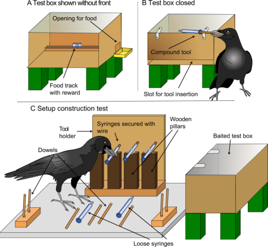

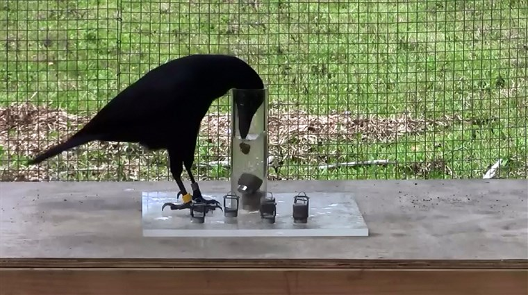

## Social learning in animals: root of culture

**Social learning = Learning by observing or interacting with other individuals**

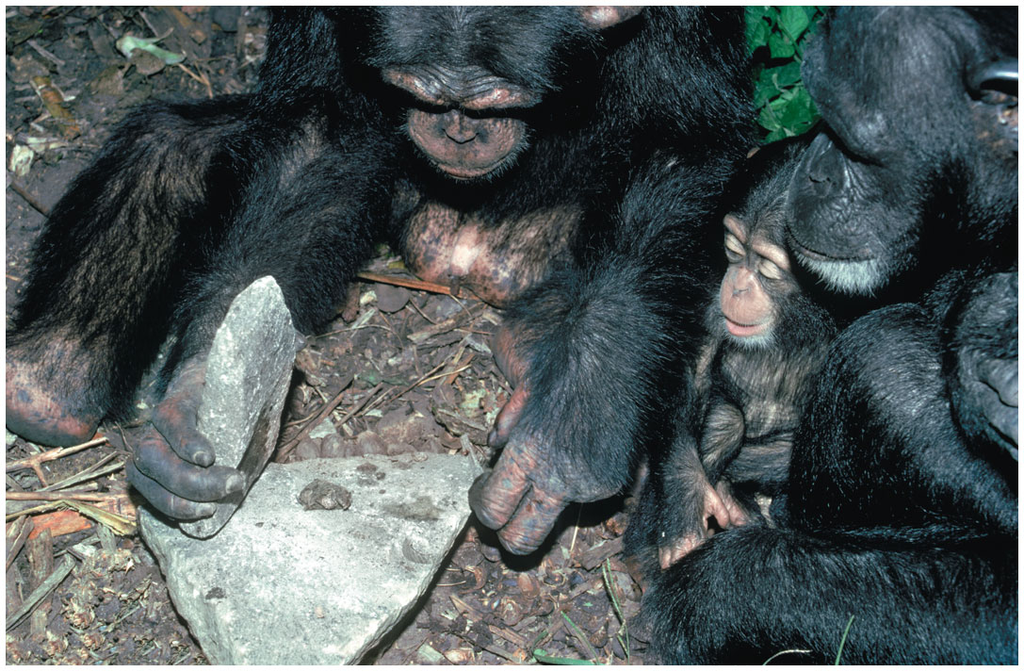

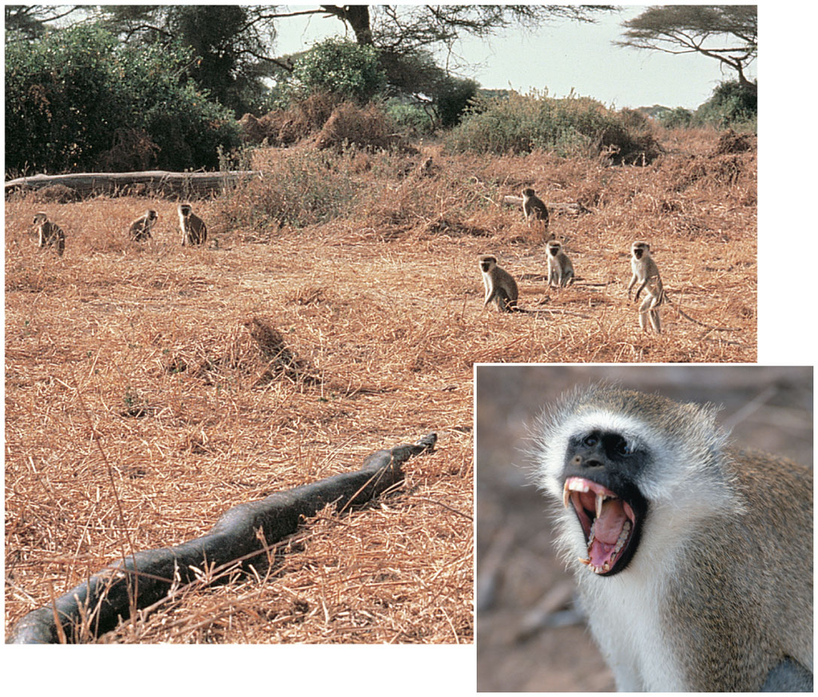

## Evolution of foraging (Tinbergen Q3: Why?)

- **Q3: How does the behavior aid survival and reproduction?**
- **Food related behaviors: eating, searching, recognizing & capture**
  - how did foraging behavior evolve?
- **Fruit flies: variation in a ‘foraging’ gene (*for*) dictates larval travel when foraging**
  - *for<sup>R</sup>* (rover) vs *for<sup>S</sup>* (sitter)
- **Which allele will be selected for in any population?**

[figure not shown]

## Evolution of mate choice (Tinbergen Q3: Why?)

- **Mate choice and mating behavior influence reproductive success**
- **Seeking, attracting & choosing mates are all under selection**
  - creates mate competition
- **Evolution of parental care produces more viable offspring**
  - monogamy vs polygamy
  - certainty of paternity
- **Mate choice behavior leads to *sexual* and *intrasexual* selection**

[figure not shown]

## How have behaviors evolved (Tinbergen Q4)

[figure not shown]

- **Behaviors have a genetic basis over the history of the species**
  - genes provide the biological capacity and constraints for behavior
- **Fruit fly courtship: series of behaviors in male flies**
  - single gene (*flu*) controls entire ritual
  - if *flu* mutated → no mating
  - variation in gene → variation in behavior
  - e.g., roles can be reversed in male and female!!!
- **Variation in environment may cause behavior to evolve**

## Are all behaviors evolved to be selfish?

- **Behaviors should be mostly selfish**
  - individual vs competitors
- **Altruism: selfless concern for others…**
  - sterile bees?
  - animals that vocalize warning calls?
- **Can unselfishness arise through natural selection?**
  - offspring survival: yours and relatives
- **Inclusive fitness: increases genetic representation of related offspring…**

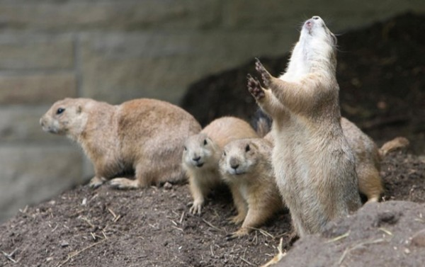